# Baker et al. (2022)’s Simulation: CS-DID vs Extended TWFE

Author

Shunkei Kakimoto

# 1 Baker, Larcker, and Wang (2022)’s Simulations

Their simulations are grouped with three aspects:

- 1. Treatment timing: Common treatment timing or Staggered interventions
- 2. Treatment effect heterogeneity:
  - (II)-(i) **Temporal heterogeneity**: constant or dynamic treatment effects over time
  - (II)-(ii) **Cohort heterogeneity**: equal or unequal treatment effects across cohorts

Here we summarize the six simulations they conducted in their paper:

| Simulation | Treatment Timing | Temporal Heterogeneity | Cohort Heterogeneity |
| --- | --- | --- | --- |
| Sim 1 | Not Staggered | Constant | No (no cohorts) |
| Sim 2 | Not Staggered | Dynamic | No (no cohorts) |
| Sim 3 | Staggered | Constant | No |
| Sim 4 | Staggered | Constant | Yes |
| Sim 5 | Staggered | Dynamic | No |
| Sim 6 | Staggered | Dynamic | Yes |

# 2 Data Generating Process: R code

I attempted to generate data as described in Equation (5) ~ (10).

## 2.1 Simulation 1 (Not Staggered)

```r
n_firms <- 1000
n_years <- 36
years <- 1980:2015
sigma_roa <- 0.309 # The empirical SD of ROA?


# /*===== Generating Base Data =====*/
gen_base_dt <- function(){
  dt <-
    CJ(firm = 1:n_firms, year = years) %>%
    .[, time_fe := rnorm(1, mean = 0, sd = .025), by = "year"] %>%
    .[, unit_fe := rnorm(1, mean = 0, sd = .5), by = "firm"] %>%
    .[, error := rnorm(.N, 0, sigma_roa)] %>%
    .[, state := sample(1:50, 1), by = "firm"]
}

# /*===========================================*/
#'=  Simulation 1 and 2 =
# /*===========================================*/
# Treatment starts in 1998
simulation1_2 <- function(base_dt) {
  # base_dt <- gen_base_dt() # Comment this out

  # treatment assignment
  treated_states <- sample(1:50, size = 25)

  base_dt[, `:=`(
    treat = as.integer(state %in% treated_states), # Treatment indicator: I[Treat]
    post_treat = as.numeric(year >= 1998) # Post treatment indicator: I[t >= 1998]
  )] %>%
  .[, G := ifelse(treat == 1, 1998, 0)] %>% # Cohort indicator (for att_gt())
  .[, event_time := year - 1998] # time since treatment

  # === Simulation 1: not staggered + constant te === #
  sim1_dt <-
    copy(base_dt) %>%
    .[, te := 0.5 * sigma_roa * treat * post_treat] %>%
    .[, y := te + unit_fe + time_fe + error]

  # === Simulation 2: not staggered + dynamic te === #
  sim2_dt <-
    copy(base_dt) %>%
    .[,te := 0.05 * sigma_roa * treat * post_treat * (year - 1997)] %>%
    .[, y := te + unit_fe + time_fe + error]

  res_dt <-
    rbind(
      "sim1" = sim1_dt,
      "sim2" = sim2_dt,
      idcol ="sim_type"
    ) %>%
    .[, .(sim_type, state, firm, year, event_time, treat, G, te, y)]

  return(res_dt)
}
```

## 2.2 simulation 3 ~ 4 (Staggerd Treatment)

```r
# /*===========================================*/
#'=  Simulation 3, 4, 5, 6 =
# /*===========================================*/
simulation3_6 <- function(base_dt) {
  # base_dt <- gen_base_dt() # Comment this out

  # Assign each state randomly to a treatment cohort
  cohort_years <- c(1989, 1998, 2007)
  state_to_cohort <-
    data.table(
      state = 1:50,
      G = sample(cohort_years, 50, replace = TRUE, prob = c(0.3, 0.4, 0.3))
    )

  # Merge cohort assignment to firms
  base_dt <- merge(base_dt, state_to_cohort, by = "state", all.x = TRUE)
  # base_dt[, .N, by = "cohort"]

  base_dt[, `:=` (
    post_treat = as.integer(year >= G), # Post treatment indicator (I[t >= G])
    event_time = year - G # Event time (time since treatment)
  )]
  # Note that the year in which the treatment initiated is counted as 1

  # Create cohort dummies: G_t
  base_dt <- fastDummies::dummy_cols(base_dt, select_columns = "G")

  #/*--------------------------------*/
  #' ## Simulation 3: Staggered + Constant/Equal
  #/*--------------------------------*/
  # homogeneous treatment effect: 0.5 * sigma_roa after treatment
  sim3_dt <-
    copy(base_dt) %>%
    .[, te :=
        0.5 * sigma_roa * (
          G_1989 * post_treat +
          G_1998 * post_treat +
          G_2007 * post_treat
        )
    ] %>%
    .[, y := te + unit_fe + time_fe + error]

  #/*--------------------------------*/
  #' ## Simulation 4: Staggered + Constant/Unequal
  #/*--------------------------------*/
  sim4_dt <-
    copy(base_dt) %>%
    .[, te :=
        sigma_roa * (
          0.5 * G_1989 * post_treat +
          0.3 * G_1998 * post_treat +
          0.1 * G_2007 * post_treat
        )
    ] %>%
    .[, y := te + unit_fe + time_fe + error]

  #/*--------------------------------*/
  #' ## Simulation 5: Staggered + Dynamic/Equal
  #/*--------------------------------*/
  sim5_dt <-
    copy(base_dt) %>%
    .[, te :=
        sigma_roa * (
          0.03 * G_1989 * post_treat +
          0.03 * G_1998 * post_treat +
          0.03 * G_2007 * post_treat
        ) * (year - G + 1)
    ] %>%
    .[, y := te + unit_fe + time_fe + error]

  #/*--------------------------------*/
  #' ## Simulation 6: Staggered + Dynamic/Unequal
  #/*--------------------------------*/
  sim6_dt <-
     copy(base_dt) %>%
     .[, te :=
         sigma_roa * (
          0.05 * G_1989 * post_treat +
          0.03 * G_1998 * post_treat +
          0.01 * G_2007 * post_treat
        ) * (year - G + 1)
      ] %>%
      .[, y := te + unit_fe + time_fe + error]

  res_dt <-
    rbind(
      "sim3" = sim3_dt,
      "sim4" = sim4_dt,
      "sim5" = sim5_dt,
      "sim6" = sim6_dt,
      idcol = "sim_type"
    ) %>%
    .[, .(sim_type, state, firm, year, event_time, G, te, y)]


  return(res_dt)
}
```

## 2.3 Mean outcome path for each simulation

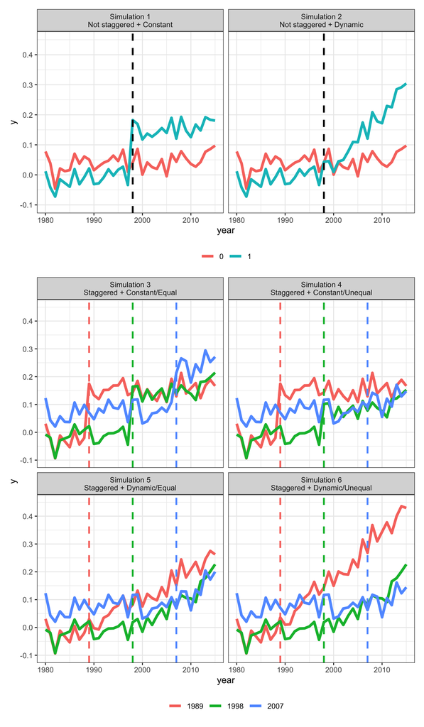

Figure 1: Trends in outcom path

```r
#/*--------------------------------*/
#' ## Vis: Outcome path
#/*--------------------------------*/
set.seed(3485)
base_data <- gen_base_dt()

sim_dt_comp <- rbind(
  simulation1_2(base_dt = copy(base_data)),
  simulation3_6(base_dt = copy(base_data)),
  fill = TRUE, use.names = TRUE
)

avg_y_path <-
  sim_dt_comp[,.(
    y = mean(y)
  ), by = .(year, treat, G, sim_type)]

# /*===== For simulatino 1 and 2 =====*/
fig_y_sim1_2 <-
  ggplot(avg_y_path[sim_type %in% c("sim1", "sim2")]) +
  geom_line(
    aes(
      x = year, y = y,
      color = factor(treat), group = factor(treat)
      ),
    linewidth  = 1.5
  ) +
  geom_vline(xintercept = 1998, linetype = "dashed", linewidth = 1) +
  facet_wrap(
    vars(sim_type),
    labeller = as_labeller(
      c(sim1 = "Simulation 1\nNot staggered + Constant",
        sim2 = "Simulation 2\nNot staggered + Dynamic")
    )
  ) +
  theme(
    legend.position = "bottom",
    legend.title = element_blank()
  )


# /*===== For simulation 3 - 6 =====*/
fig_y_sim3_6 <-
  ggplot(avg_y_path[sim_type %in% paste0("sim", 3:6)]) +
  geom_line(
    aes(
      x = year, y = y,
      color = factor(G), group = factor(G)
      ),
      linewidth = 1.5
  ) +
  geom_vline(
    aes(xintercept = G, color = factor(G)),
    linetype = "dashed", linewidth = 1,
    show.legend = FALSE
  ) +
  facet_wrap(
    vars(sim_type), ncol = 2,
    labeller = as_labeller(
      c(sim3 = "Simulation 3\nStaggered + Constant/Equal",
        sim4 = "Simulation 4\nStaggered + Constant/Unequal",
        sim5 = "Simulation 5\nStaggered + Dynamic/Equal",
        sim6 = "Simulation 6\nStaggered + Dynamic/Unequal")
    )
  ) +
  theme(
    legend.position = "bottom",
    legend.title = element_blank()
  )

# /*===== figure =====*/
fig_y_sim1_2 / fig_y_sim3_6 +
  plot_layout(heights = c(2, 4)) & ylim(-0.1, 0.45)
```

# 3 Simulation: CS-DID vs Extended TWFE

## 3.1 Functions to run CS-DID and Extended TWFE

- Control group is “not-yet-treated” group
- From the year 2007, all states are treated. Thus, treatment effects for the last cohorts are not identified. For cohort 1989 and 1998, treatment effects are identified until 2006.

```r
# set.seed(1125)
# base_dt <- gen_base_dt()


# /*===========================================*/
#'=  CS-DID =
# /*===========================================*/
run_cs <- function(reg_dt){
  #/*--------------------------------*/
  #' ## Test Run
  # set.seed(1234)
  # test_case_dt <- simulation3_6(base_dt)
  # reg_dt <- test_case_dt[sim_type == "sim3"]
  #/*--------------------------------*/
  cs_att_gt <-
    att_gt(
      yname = "y",
      gname = "G",
      idname = "firm",
      tname = "year",
      data = reg_dt,
      xformla = ~1,
      control_group = "notyettreated",
      est_method = "dr"
    )

  # === ATT(g,t) === #
  cs_att_gt_out <-
    tidy(cs_att_gt) %>%
    data.table() %>%
    .[, .(G = group, year = time, estimate)]

  # === Mean Post-treatment effects (5 years) === #
  # Extract 5 years post-treatment
  # cs_static_att <- mean(cs_att_gt_out[year >= G  & year <= G + 4, estimate])

  # === ATT(g) === #


  # === ATT(e) === #



  # === Outputs === #
  return(
    tibble(
      method = "cs",
      att_gt = list(cs_att_gt_out)
      # static_att = cs_static_att
    )
  )
}


# /*===========================================*/
#'=  Extended TWFE =
# /*===========================================*/
run_extwfe <- function(reg_dt){
  #/*--------------------------------*/
  #' ## Test Run
  # set.seed(1234)
  # test_case_dt <- simulation3_6(base_dt)
  # reg_dt <- test_case_dt[sim_type == "sim3"]
  #/*--------------------------------*/
  etwfe_att_gt <-
    etwfe(
      fml = y ~ 1,
      tvar = year,
      gvar = G,
      data = reg_dt,
      cgroup = "notyet"
    )

  # which is equivalent to:
  # extwfe_att_gt <-
  #   feols(
  #     y ~ post_treat : factor(event_time) : factor(G) | firm + year,
  #     data = reg_dt,
  #     notes = FALSE # Suppress the message
  #   )

  # extwfe_att_gt_out <-
  #   tidy(etwfe_att_gt) %>%
  #   as.data.table() %>%
  #   .[, G := as.numeric(gsub(".*G.", "", term))] %>%
  #   .[, year := as.numeric(gsub(".*event_time.(\\d+).*", "\\1", term)) + G] %>%
  #   .[,.(G, year, estimate)] %>%
  #   .[year < 2007,]

  # === ATT(g,t) === #
  etwfe_att_gt_out <-
    tidy(etwfe_att_gt) %>%
    data.table() %>%
    .[, G := as.numeric(gsub(".*G::(\\d+):.*", "\\1", term))] %>%
    .[, year := as.numeric(gsub(".*year::(\\d+)", "\\1", term))] %>%
    .[, .(G, year, estimate)]

  # === Mean Post-treatment effects (5 years) === #
  # Extract 5 years post-treatment
  # etwfe_static_att <- mean(etwfe_att_gt_out[year >= G  & year <= G + 4, estimate])

  # === ATT(g) === #


  # === ATT(e) === #



  # === Outputs === #
  return(
    tibble(
      method = "etwfe",
      att_gt = list(etwfe_att_gt_out)
      # static_att = etwfe_static_att
    )
  )
}
```

```r
# label: define-run-sim-comp

run_sim_comp <- function(){

  base_dt <- gen_base_dt()

  ls_sim_dt_comp <-
    rbindlist(
      list(
        simulation1_2(base_dt = copy(base_dt)),
        simulation3_6(base_dt = copy(base_dt))
      ),
      use.names = TRUE,
      fill = TRUE
    ) %>%
    split(., by = "sim_type")

  true_att_gt <-
    lapply(
      ls_sim_dt_comp,
      \(x) x[, .(att_gt = mean(te)), by = .(G, year)]
    )

  case_dt <-
    tibble(
      case = names(ls_sim_dt_comp),
      reg_dt = ls_sim_dt_comp,
      true_att = true_att_gt
    )

  case_dt <-
    case_dt %>%
    mutate(
      res_cs = lapply(
        1:nrow(.),
        \(i) run_cs(reg_dt = .$reg_dt[[i]])
      ),
      res_etwfe = lapply(
        1:nrow(.),
        \(i) run_extwfe(reg_dt = .$reg_dt[[i]])
      )
    ) %>%
    select(!reg_dt)
}

# test <-
#   lapply(1:2, \(x) run_sim_comp()) %>%
#   rbindlist(idcol = "sim")

# test_case6 <- filter(test, case == "sim6")

# test_case6$true_att[[1]]
# test_case6$true_att[[2]]
```

## 3.2 Run 500 times simulation

```r
# xs <- 1:500

# with_progress({
#   p <- progressor(along = xs)

#   res_sim_comp <-
#     future_lapply(
#       xs,
#       \(x){
#         p()
#         run_sim_comp()
#       },
#       future.seed = NULL
#     ) %>%
#     rbindlist(idcol = "sim")
# })

# saveRDS(
#   res_sim_comp,
#   here("Data/Processed/sim_baker2022.rds")
# )

res_sim_comp <- readRDS(here("Data/Processed/sim_baker2022.rds"))

#/*--------------------------------*/
#' ## Results
#/*--------------------------------*/
res_true_att_gt <-
  res_sim_comp %>%
  select(sim, case, true_att) %>%
  unnest("true_att") %>%
  data.table()
  # .[, `:=`(
  #   case_label = paste0("Simulation ", sim),
  #   gt_label = paste0("G = ", G, " Year = ", year)
  # )]


res_cs_att_gt <-
  res_sim_comp %>%
  select(sim, case, res_cs) %>%
  unnest("res_cs") %>%
  unnest("att_gt") %>%
  data.table()
  # .[, `:=`(
  #   case_label = paste0("Simulation ", sim),
  #   gt_label = paste0("G = ", G, " Year = ", year)
  # )]



res_etwfe_att_gt <-
  res_sim_comp %>%
  select(sim, case, res_etwfe) %>%
  unnest("res_etwfe") %>%
  unnest("att_gt") %>%
  data.table()
  # .[, `:=`(
  #   case_label = paste0("Simulation ", sim),
  #   gt_label = paste0("G = ", G, " Year = ", year)
  # )]
```

# 4 Results

## 4.1 Static Effect Estimates (Figure 6 in Baker, Larcker, and Wang (2022))

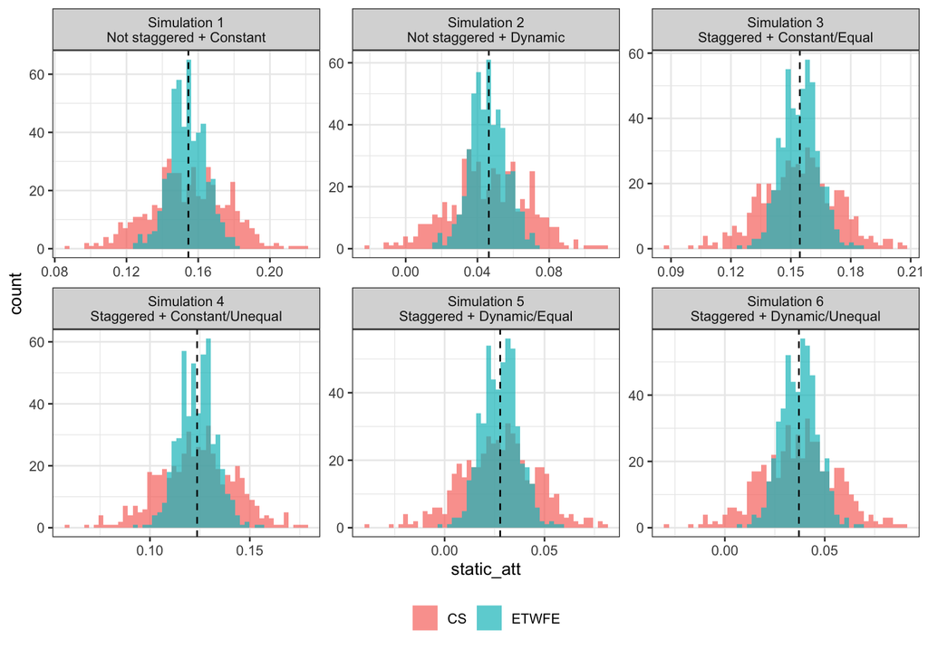

Figure 2: Distribution of static effect estimates of CS-DID and Extended TWFE

```r
# === Mean Post-treatment effects (5 years) === #
# Extract 5 years post-treatment
true_att_gt_static <-
  res_true_att_gt %>%
  .[G %in% c(1989, 1998),] %>%
  .[year >= G  & year <= G + 4, ] %>%
  .[, .(true_att_static = mean(att_gt)), by = case]


cs_att_gt_static <-
  res_cs_att_gt %>%
  .[G %in% c(1989, 1998),] %>%
  .[year >= G  & year <= G + 4, ] %>%
  .[, .(static_att = mean(estimate)), by = .(sim, case, method)]


etwfe_att_gt_static <-
  res_etwfe_att_gt %>%
  .[G %in% c(1989, 1998),] %>%
  .[year >= G  & year <= G + 4, ] %>%
  .[, .(static_att = mean(estimate)), by = .(sim, case, method)]


att_gt_static <- rbind(cs_att_gt_static, etwfe_att_gt_static)

#/*--------------------------------*/
#' ## Vidualization
#/*--------------------------------*/
case_labels <- c(
  sim1 = "Simulation 1\nNot staggered + Constant",
  sim2 = "Simulation 2\nNot staggered + Dynamic",
  sim3 = "Simulation 3\nStaggered + Constant/Equal",
  sim4 = "Simulation 4\nStaggered + Constant/Unequal",
  sim5 = "Simulation 5\nStaggered + Dynamic/Equal",
  sim6 = "Simulation 6\nStaggered + Dynamic/Unequal"
  )



ggplot() +
  geom_histogram(
    data = att_gt_static[method == "cs"],
    aes(static_att, fill = "CS"),
    alpha = 0.7, bins = 50
  ) +
  geom_histogram(
    data = att_gt_static[method == "etwfe"],
    aes(static_att, fill = "ETWFE"),
    alpha = 0.7, bins = 50
  ) +
  geom_vline(
    data = true_att_gt_static,
    aes(xintercept = true_att_static),
    linetype = "dashed"
  ) +
  facet_wrap(
    vars(case), scale = "free",
    labeller = as_labeller(case_labels)
  ) +
  fig_theme



# This does not work
# ggplot(att_gt_static) +
#   geom_histogram(
#     aes(static_att, fill = method),
#     alpha = 0.7, bins = 50
#   ) +
#   geom_vline(
#     data = true_att_gt_static,
#     aes(xintercept = true_att_static),
#     linetype = "dashed"
#   ) +
#   facet_wrap(
#     vars(case), scale = "free",
#     labeller = as_labeller(case_labels)
#   )
```

**Note**

- Figure 6 in the paper shows the distribution of static treatment effect estimates, defined as **the average treatment effect over the five years following treatment**. For each simulated dataset, a single scalar ATT estimate is computed based on the ATT(g,t) estimates from CS-DID and ETWFE by aggregating the ATT(g,t) estimates over this five-year post-treatment window.
- I guess they wanted to compare to compare these alternative estimators directly to the traditional TWFE DiD estimates shown in Figures 1 and 2.

## 4.2 ATT(g,t) for simulation 3 ~ 6

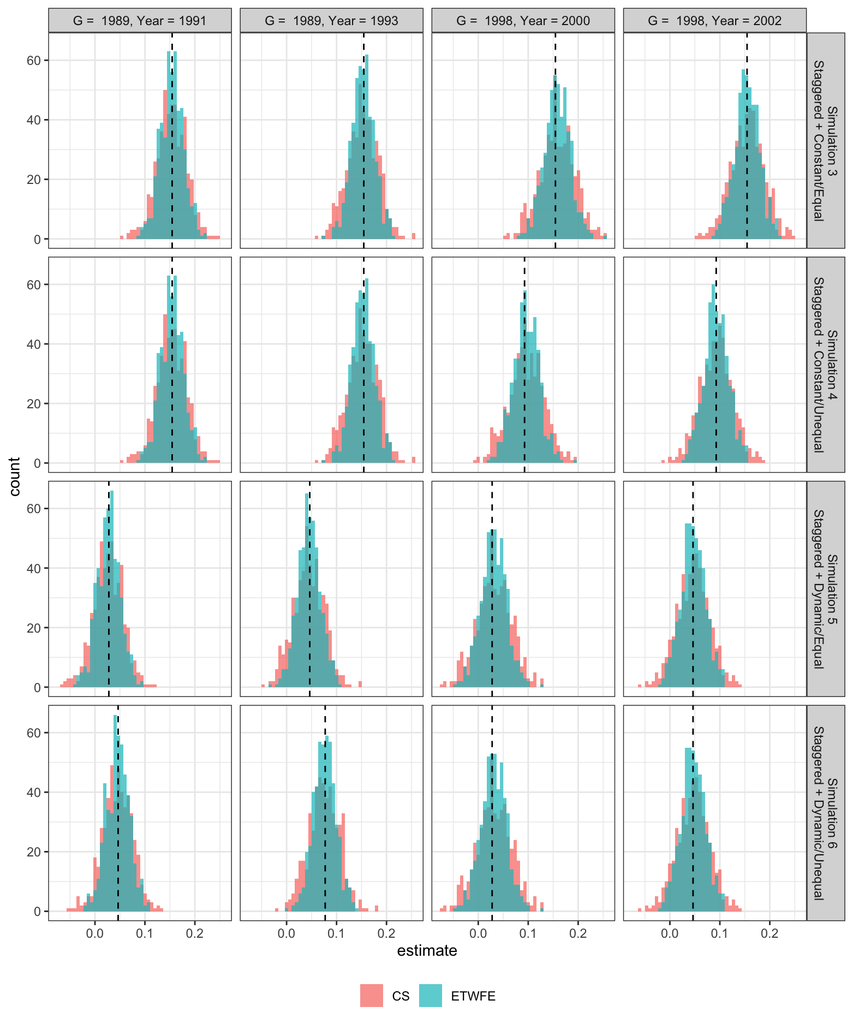

Figure 3: Estimated ATT(g,t) for selected (g,t) combinations

```r
# tg_years <- c(
#   1993, # 5 years after 1989
#   2002 # 5 years after 1998
# )

true_att_gt <-
  res_true_att_gt %>%
  .[case %in% paste0("sim", 3:6)] %>%
  .[
    G == 1989 & year == 1991 |
    G == 1989 & year == 1993|
    G == 1998 & year == 2000 |
    G == 1998 & year == 2002
  ] %>%
  .[, .(true_att_gt = mean(att_gt)), by = .(case, G, year)] %>%
  .[, group := paste0("G =  ", G, ", Year = ", year)]


# res_cs_att_gt[case %in% paste0("sim", 3:6) & G == 1989 & year == 1993, ]
# res_cs_att_gt[case %in% paste0("sim", 3:6) & G == 1998 & year == 2002, ]

# res_etwfe_att_gt[case %in% paste0("sim", 3:6) & G == 1989 & year == 1993, ]
# res_etwfe_att_gt[case %in% paste0("sim", 3:6) & G == 1998 & year == 2002, ]



est_att_gt <-
  rbind(res_cs_att_gt, res_etwfe_att_gt) %>%
  .[case %in% paste0("sim", 3:6)] %>%
  .[
    G == 1989 & year == 1991 |
    G == 1989 & year == 1993|
    G == 1998 & year == 2000 |
    G == 1998 & year == 2002
  ] %>%
  .[, group := paste0("G =  ", G, ", Year = ", year)]

# unique(est_att_gt[,.(method, G, year)])
# est_att_gt[,.N, by = .(method, G, year)]


# ggplot(est_att_gt[G == 1989 & case == "sim3"]) +
#    geom_histogram(
#       aes(estimate, fill = method), bins = 50, alpha = 0.5
#     )


ggplot() +
    geom_histogram(
      # data = est_att_gt[G == 1989 & case == "sim3" & method == "cs"],
      data = est_att_gt[method == "cs"],
      aes(estimate, fill = "CS"),
      alpha = 0.7, bins = 50
    ) +
    geom_histogram(
      # data = est_att_gt[G == 1989 & case == "sim3" & method == "etwfe"],
      data = est_att_gt[method == "etwfe"],
      aes(estimate, fill = "ETWFE"),
      alpha = 0.7, bins = 50
    ) +
    geom_vline(
      data = true_att_gt,
      aes(xintercept = true_att_gt),
      linetype = "dashed"
    ) +
    facet_grid(
      case ~ group,
      labeller = labeller(case = case_labels)
    ) +
    fig_theme
```

## 5 References

Baker, Andrew C., David F. Larcker, and Charles C. Y. Wang. 2022. “How Much Should We Trust Staggered Difference-in-Differences Estimates?” *Journal of Financial Economics* 144 (2): 370–95. https://doi.org/10.1016/j.jfineco.2022.01.004.